# RSQSim on TPV14 branched-fault benchmark

# RMarkdown setup

```r
library(knitr)
knitr::opts_chunk$set(cache = TRUE, cache.lazy = FALSE, warning=FALSE,
                      fig.width=6, fig.height=6, autodep=TRUE)
```

## Function to build the fault geometry

```r
buildFault = function(l=400, setoff=0, rundir="TPV14", run=1) {

  # through fault
  x0 = 0
  y0 = 0
  z0 = 0
  L = 28e3
  W = 15e3
  l = w = 400
  nl = round(L/l)
  nw = round(W/w)
  strike = 0
  dip = 90
  rake = 180
  ddot = 0
  sectNum = 1

  system2("/Users/dinger/RSQSim.github.master/BuildFaultModels/singlePlanarFault",
          args=c(x0, y0, z0, L, W, nl, nw, strike, dip, rake, ddot, sectNum),
          stdout=file.path(rundir, "fault1.flt"))

  # branch fault

  strike = 30
  x0 = setoff * sin(strike*pi/180)
  y0 = 16e3 + setoff * cos(strike*pi/180)
  z0 = 0
  L = 12e3
  nl = round(L/l)
  nw = round(W/w)
  strike = 30
  sectNum = 2
  system2("/Users/dinger/RSQSim.github.master/BuildFaultModels/singlePlanarFault",
          args=c(x0, y0, z0, L, W, nl, nw, strike, dip, rake, ddot, sectNum),
          stdout=file.path(rundir, "fault2.flt"))

  system2("cat", args=c(file.path(rundir, "fault1.flt"),
                        file.path(rundir, "fault2.flt")),
          stdout=file.path(rundir, paste0("faults.flt")))

  unlink(c(file.path(rundir, "fault1.flt"),
           file.path(rundir, "fault2.flt")))

  flt = readFault(file.path(rundir, "faults.flt"))
  return(flt)
}
```

# Function to set up initial stresses

Note that the 3 km x 3 km nucleation region centered on $y$ = 8 km, $z$ = -7.5 km may or may not fit exactly in a mesh with a given side length.

```r
initStresses = function(flt, sigma=rep(120, length(unique(flt$iseg))),
                        tau=rep(70, length(unique(flt$iseg))),
                        ynuc=8000, znuc=-7500, wnuc=1500, segnuc=1, taunuc=81.6) {
  sigma.out = sigma[flt$iseg]
  write(sigma.out, file=file.path(rundir, "initSigma.txt"), ncol=1)

  tau.out = tau[flt$iseg]
  nuc = which(flt$iseg == segnuc & abs(flt$z - znuc) <= wnuc & abs(flt$y - ynuc) <= wnuc)
  tau.out[nuc] = taunuc
  write(tau.out, file=file.path(rundir, "initTau.txt"), ncol=1)

}
```

# Elastic modulii

These are simple and the same for all the runs we’ll be doing here.

TPV14 (and TPV15) use $\rho = 2670 \mathrm{kg}/\mathrm{m}^3$, $V_s$ = 3464 m/s, and $V_p$ = 6000 m/s. RSQSim needs the Lame parameters $\lambda$ and $\mu$. In terms of the density and wave speeds these are

$$\begin{align}
\mu &= \rho V_s^2 \\
\lambda &= \rho \left( V_p^2 - 2V_s^2 \right)
\end{align}$$

```r
rho = 2670
Vs = 3464
Vp = 6000

lameMu = rho * Vs*Vs / 1e6 # in MPa
lameLambda = rho * (Vp*Vp - 2*Vs*Vs) / 1e6
```

# Friction parameters and initial state

We will use our usual fixed values of $V^\mathrm{EQ}$ (though will definitely want to try variable $V^\mathrm{EQ}$ eventually) of 1 m/s (update: given the specified $V_s$, $\Delta\tau$, and shear modulus, the shear impedance relation implies a slip speed of 1.57 m/s, but I have adjusted it to 1.2 m/s to better match the rupture propagation speed seen in the dynamic models), $V^\ast$ of $10^{-6}$ m/s, $D_c$ of $10^{-5}$ m, $a$ of 0.01, and $b$ of 0.015. Then we will choose $\mu_0$, and $\theta_0$ from the two equations in http://rsqsim.ucr.edu/wiki/index.php/Stress_drops_in_artificially_nucleated_events#Further_attempt_at_more_accurate_estimate_of:

$$\begin{align}
\mu_0 &= \frac{\tau_f}{\sigma} + \left(b-a\right)\ln\left(\frac{V^\mathrm{EQ}}{V^\ast}\right) \\
\theta_0 &= \left(\frac{D_c}{V^\ast}\right)^\frac{b-a}{b-a+a^\prime} \left(\frac{l b \sigma}{G V^\mathrm{EQ}}\right)^\frac{a^\prime}{b-a+a^\prime} \exp\left(\frac{\tau_p/\sigma - \mu_0}{b -a +a^\prime}\right)
\end{align}$$

And then force the nucleation region to fail immediately at its initial shear stress level by lowering $\theta$ there by the appropriate amount. RSQSim can do that automatically, but I’ll just calculate the numbers here and write out an initial $\theta$ file instead.

The approx for $\tau_f$ is known to be pretty rough, so after an initial run showed that the final $\tau$ was about 2.6 MPa too high, I adjusted the $\tau_f$ in the formula for $\mu_0$ above by this amount (in code block below).

For TPV14 (and TPV15) we have that $\tau_p = \mu_s \sigma = 0.677 \cdot 120 \mbox{ MPa} = 81.24 \mbox{ MPa}$ and $\tau_f = \mu_d \sigma = 0.525 \cdot 120 \mbox{ MPa} = 63 \mbox{ MPa}$.

```r
fricTheta0 = function(flt, rundir, mus=0.677, mud=0.525, sigma=120,
                      VEQ=1.22, Vstar=1e-6, Dc=1e-5, a=0.01, fa=0.1, b=0.015,
                      dtauf = -2.6,
                      ynuc=8000, znuc=-7500, wnuc=1500, segnuc=1) {
  taup = mus * sigma[1]
  tauf = mud * sigma[1]

  aprime = fa*a

  mu0 = (tauf + dtauf)/sigma[1] + (b-a)*log(VEQ/Vstar)
  theta0 = (Dc/Vstar)^((b-a)/(b-a+aprime)) * ((l*b*sigma[1])/(lameMu*VEQ))^((aprime)/(b-a+aprime)) *
            exp( (taup/sigma[1] - mu0)/(b - a + aprime) )

  theta.nuc = RStheta(Vstar, mu0, taup, sigma[1], a, b, VEQ, Dc)

  theta = rep(theta0, flt$np)

  nuc = which(flt$iseg == segnuc & abs(flt$z - znuc) <= wnuc & abs(flt$y - ynuc) <= wnuc)
  theta[nuc] = theta.nuc
  write(theta, file=file.path(rundir, "initTheta.txt"))

  return(mu0)
}
```

# Building the RSQSim input file

```r
buildRSQSimInputFile =
  function(rundir, run, a, b, Dc, mu0, ddotStar, VEQ, lameLambda, lameMu) {

  unlink("eqs..out")
  system2("/Users/dinger/RSQSim.github.master/runRSQSim", stdout=NULL, stderr=NULL)
  eqs = readEqs("eqs..out", saveRData=FALSE)
  unlink(c("eqs..out", "eqs..out.RData", ".Screen.Time.out", ".times_saved.out"))
  params = eqs$params
  rm(eqs)

  params$A_1 = a
  params$B_1 = b
  params$Dc_1 = Dc
  params$mu0_1 = mu0
  params$ddotStar_1 = Vstar
  params$alpha_1 = 0.25
  params$ddotEQ_1 = VEQ
  params$lameLambda = lameLambda
  params$lameMu = lameMu
  params$nEq = 1
  params$faultFname = "faults.flt"
  params$outFnameInfix = paste0("TPV14.run", run)
  params$writeTau = 2
  params$writeSigma = 2
  params$initTauFname = "initTau.txt"
  params$initSigmaFname = "initSigma.txt"
  params$initThetaFname = "initTheta.txt"

  writeRSQSimInputFile(params, file.path(rundir, paste0("TPV14.run", run, ".in")))
}
```

# Run 1

Note that with 1 km elements and set up as below, rupture would not propagate away from nucleation region. Currently using 400 m elements.

400 m elements, setoff of zero

```r
run = 1
rundir = file.path("TPV14", paste0("Run", run))
system(paste("mkdir -p", rundir))

l = 400
setoff = 0
ynuc = 8000
znuc = -7500
wnuc = 1500
segnuc = 1
taunuc = 81.6
mus = 0.677
mud = 0.525
initSigma = c(120, 120)
initTau = c(70, 70)
VEQ = 1.22 # note: usual default is 1.0, shear impedance in this case says 1.57
Vstar = 1e-6
Dc = 1e-5
a = 0.01
fa = 0.1
b = 0.015
dtauf = -2.6

flt1 = buildFault(l=l, setoff=setoff, rundir=rundir)
initStresses(flt1, initSigma, initTau,
             ynuc=ynuc, znuc=znuc, wnuc=wnuc, segnuc=segnuc, taunuc=taunuc)
mu0 = fricTheta0(flt1, rundir, mus=mus, mud=mud, sigma=initSigma,
                 VEQ=VEQ, Vstar=Vstar, Dc=Dc, a=a, fa=fa, b=b,
                      dtauf = dtauf,
                      ynuc=ynuc, znuc=znuc, wnuc=wnuc, segnuc=segnuc)
buildRSQSimInputFile(rundir=rundir, run=run, a=a, b=b, Dc=Dc, mu0=mu0,
                     ddotStar=ddotStar, VEQ=VEQ,
                     lameLambda=lameLambda, lameMu=lameMu)
```

```
## [1] "Warning: /Users/dinger/Proposals/2019SCEC-branch/SCEC_CVS/faults.in doesn't exist"
```

```r
here = getwd()
setwd(rundir)
unlink("eqs*out")
system2("mpirun",
        args=c("-np", 4, "/Users/dinger/RSQSim.github.master/runRSQSim",
               paste0("TPV14.run", run, ".in")),
        stderr=paste0("run", run, ".stderr"),
        stdout=paste0("run", run, ".stdout"))
eqs1 = readEqs(paste0("eqs.TPV14.run", run, ".out"))
setwd(here)
```

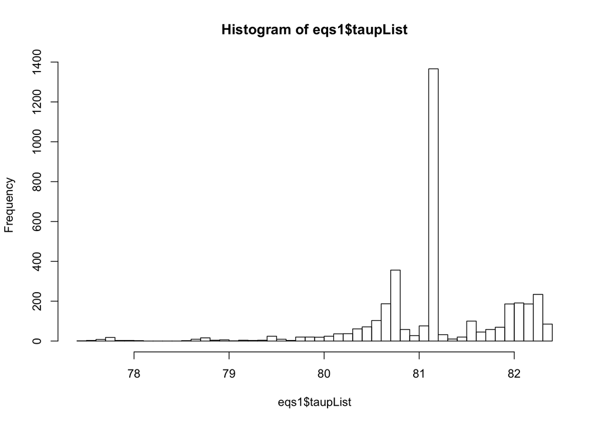

```r
hist(eqs1$taupList, breaks="FD")
```

```r
c(mean(eqs1$taupList), mus*initSigma[1])
```

```
## [1] 81.18439 81.24000
```

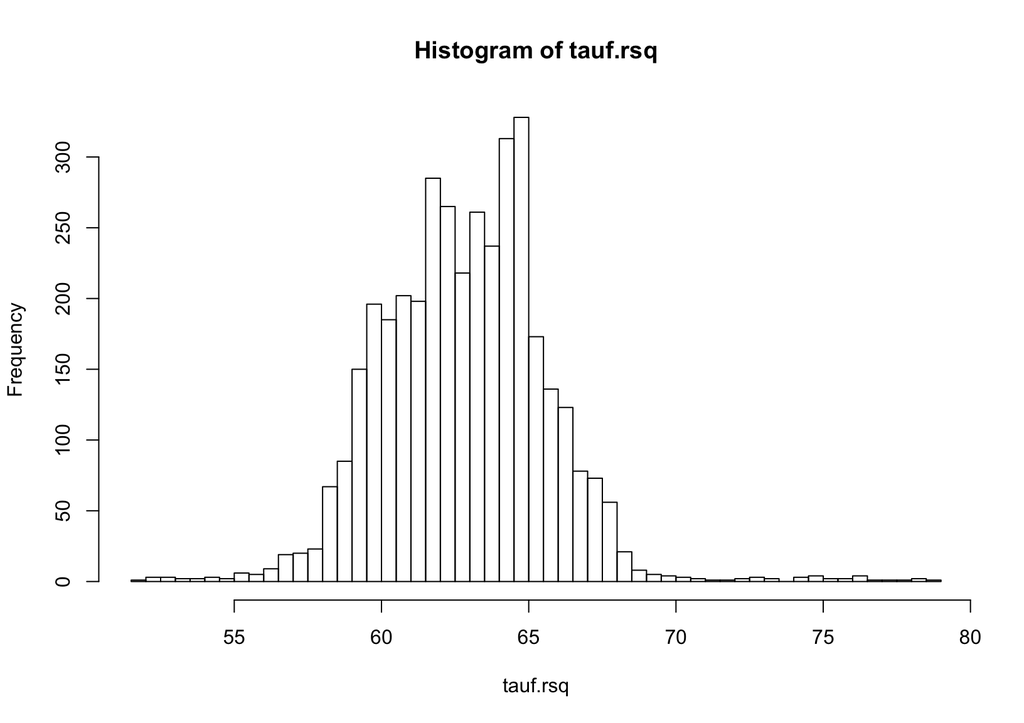

```r
tauf.rsq = readFaultVal(eqs1, val="tau", writeVal="final")$val[1,]
hist(tauf.rsq, breaks="FD")
```

```r
c(mean(tauf.rsq), mud*initSigma[1])
```

```
## [1] 62.84159 63.00000
```

# Run 2

100 m set off to branch fault

```r
run = 2
rundir = file.path("TPV14", paste0("Run", run))
system(paste("mkdir -p", rundir))

setoff = 100

flt2 = buildFault(l=l, setoff=setoff, rundir=rundir)
initStresses(flt2, initSigma, initTau,
             ynuc=ynuc, znuc=znuc, wnuc=wnuc, segnuc=segnuc, taunuc=taunuc)
mu0 = fricTheta0(flt2, rundir, mus=mus, mud=mud, sigma=initSigma,
                 VEQ=VEQ, Vstar=Vstar, Dc=Dc, a=a, fa=fa, b=b,
                      dtauf = dtauf,
                      ynuc=ynuc, znuc=znuc, wnuc=wnuc, segnuc=segnuc)
buildRSQSimInputFile(rundir=rundir, run=run, a=a, b=b, Dc=Dc, mu0=mu0,
                     ddotStar=ddotStar, VEQ=VEQ,
                     lameLambda=lameLambda, lameMu=lameMu)
```

```
## [1] "Warning: /Users/dinger/Proposals/2019SCEC-branch/SCEC_CVS/faults.in doesn't exist"
```

```r
here = getwd()
setwd(rundir)
unlink("eqs*out")
system2("mpirun",
        args=c("-np", 4, "/Users/dinger/RSQSim.github.master/runRSQSim",
               paste0("TPV14.run", run, ".in")),
        stderr=paste0("run", run, ".stderr"),
        stdout=paste0("run", run, ".stdout"))
eqs2 = readEqs(paste0("eqs.TPV14.run", run, ".out"))
setwd(here)
```

# Run 3

200 m set off to branch fault

```r
run = 3
rundir = file.path("TPV14", paste0("Run", run))
system(paste("mkdir -p", rundir))

setoff = 200

flt = buildFault(l=l, setoff=setoff, rundir=rundir)
initStresses(flt, initSigma, initTau,
             ynuc=ynuc, znuc=znuc, wnuc=wnuc, segnuc=segnuc, taunuc=taunuc)
mu0 = fricTheta0(flt, rundir, mus=mus, mud=mud, sigma=initSigma,
                 VEQ=VEQ, Vstar=Vstar, Dc=Dc, a=a, fa=fa, b=b,
                      dtauf = dtauf,
                      ynuc=ynuc, znuc=znuc, wnuc=wnuc, segnuc=segnuc)
buildRSQSimInputFile(rundir=rundir, run=run, a=a, b=b, Dc=Dc, mu0=mu0,
                     ddotStar=ddotStar, VEQ=VEQ,
                     lameLambda=lameLambda, lameMu=lameMu)
```

```
## [1] "Warning: /Users/dinger/Proposals/2019SCEC-branch/SCEC_CVS/faults.in doesn't exist"
```

```r
here = getwd()
setwd(rundir)
unlink("eqs*out")
system2("mpirun",
        args=c("-np", 4, "/Users/dinger/RSQSim.github.master/runRSQSim",
               paste0("TPV14.run", run, ".in")),
        stderr=paste0("run", run, ".stderr"),
        stdout=paste0("run", run, ".stdout"))
eqs3 = readEqs(paste0("eqs.TPV14.run", run, ".out"))
setwd(here)
```

# Run 4

300 m set off to branch fault

```r
run = 4
rundir = file.path("TPV14", paste0("Run", run))
system(paste("mkdir -p", rundir))

setoff = 300

flt = buildFault(l=l, setoff=setoff, rundir=rundir)
initStresses(flt, initSigma, initTau,
             ynuc=ynuc, znuc=znuc, wnuc=wnuc, segnuc=segnuc, taunuc=taunuc)
mu0 = fricTheta0(flt, rundir, mus=mus, mud=mud, sigma=initSigma,
                 VEQ=VEQ, Vstar=Vstar, Dc=Dc, a=a, fa=fa, b=b,
                      dtauf = dtauf,
                      ynuc=ynuc, znuc=znuc, wnuc=wnuc, segnuc=segnuc)
buildRSQSimInputFile(rundir=rundir, run=run, a=a, b=b, Dc=Dc, mu0=mu0,
                     ddotStar=ddotStar, VEQ=VEQ,
                     lameLambda=lameLambda, lameMu=lameMu)
```

```
## [1] "Warning: /Users/dinger/Proposals/2019SCEC-branch/SCEC_CVS/faults.in doesn't exist"
```

```r
here = getwd()
setwd(rundir)
unlink("eqs*out")
system2("mpirun",
        args=c("-np", 4, "/Users/dinger/RSQSim.github.master/runRSQSim",
               paste0("TPV14.run", run, ".in")),
        stderr=paste0("run", run, ".stderr"),
        stdout=paste0("run", run, ".stdout"))
eqs4 = readEqs(paste0("eqs.TPV14.run", run, ".out"))
setwd(here)
```

# Run 5

400 m set off to branch fault (doing this because this is one of our elements, which what TPV14 did - but with smaller elements)

```r
run = 5
rundir = file.path("TPV14", paste0("Run", run))
system(paste("mkdir -p", rundir))

setoff = 400

flt = buildFault(l=l, setoff=setoff, rundir=rundir)
initStresses(flt, initSigma, initTau,
             ynuc=ynuc, znuc=znuc, wnuc=wnuc, segnuc=segnuc, taunuc=taunuc)
mu0 = fricTheta0(flt, rundir, mus=mus, mud=mud, sigma=initSigma,
                 VEQ=VEQ, Vstar=Vstar, Dc=Dc, a=a, fa=fa, b=b,
                      dtauf = dtauf,
                      ynuc=ynuc, znuc=znuc, wnuc=wnuc, segnuc=segnuc)
buildRSQSimInputFile(rundir=rundir, run=run, a=a, b=b, Dc=Dc, mu0=mu0,
                     ddotStar=ddotStar, VEQ=VEQ,
                     lameLambda=lameLambda, lameMu=lameMu)
```

```
## [1] "Warning: /Users/dinger/Proposals/2019SCEC-branch/SCEC_CVS/faults.in doesn't exist"
```

```r
here = getwd()
setwd(rundir)
unlink("eqs*out")
system2("mpirun",
        args=c("-np", 4, "/Users/dinger/RSQSim.github.master/runRSQSim",
               paste0("TPV14.run", run, ".in")),
        stderr=paste0("run", run, ".stderr"),
        stdout=paste0("run", run, ".stdout"))
eqs5 = readEqs(paste0("eqs.TPV14.run", run, ".out"))
setwd(here)
```

# Rupture time plots

## 400 m elements

### Branch fault touches main fault

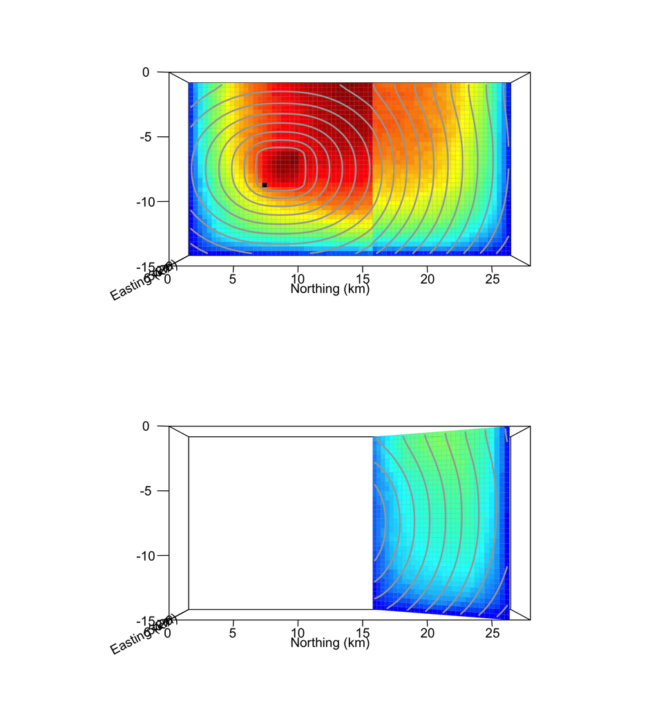

### Branch fault 100 m away from main fault

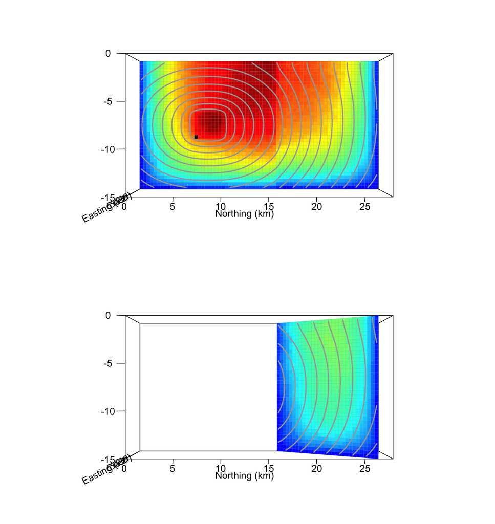

### Branch fault 200 m away from main fault

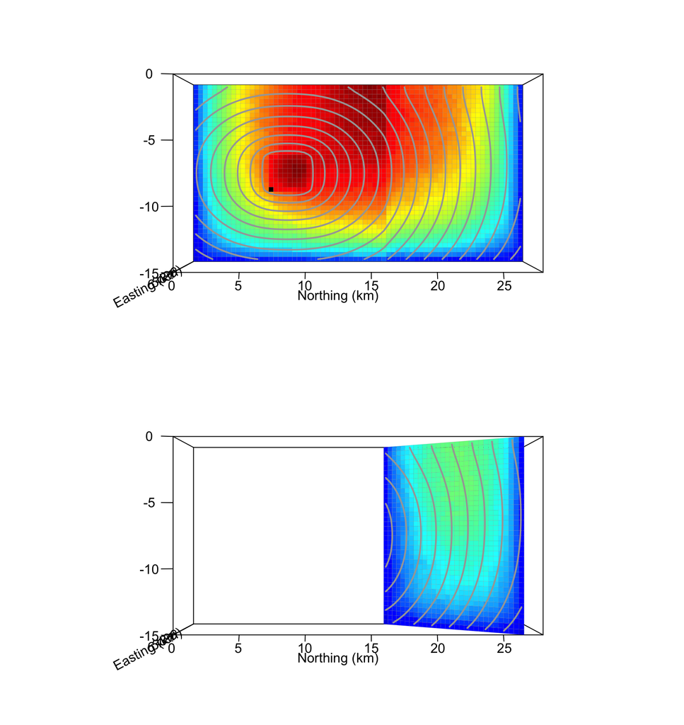

### Branch fault 300 m away from main fault

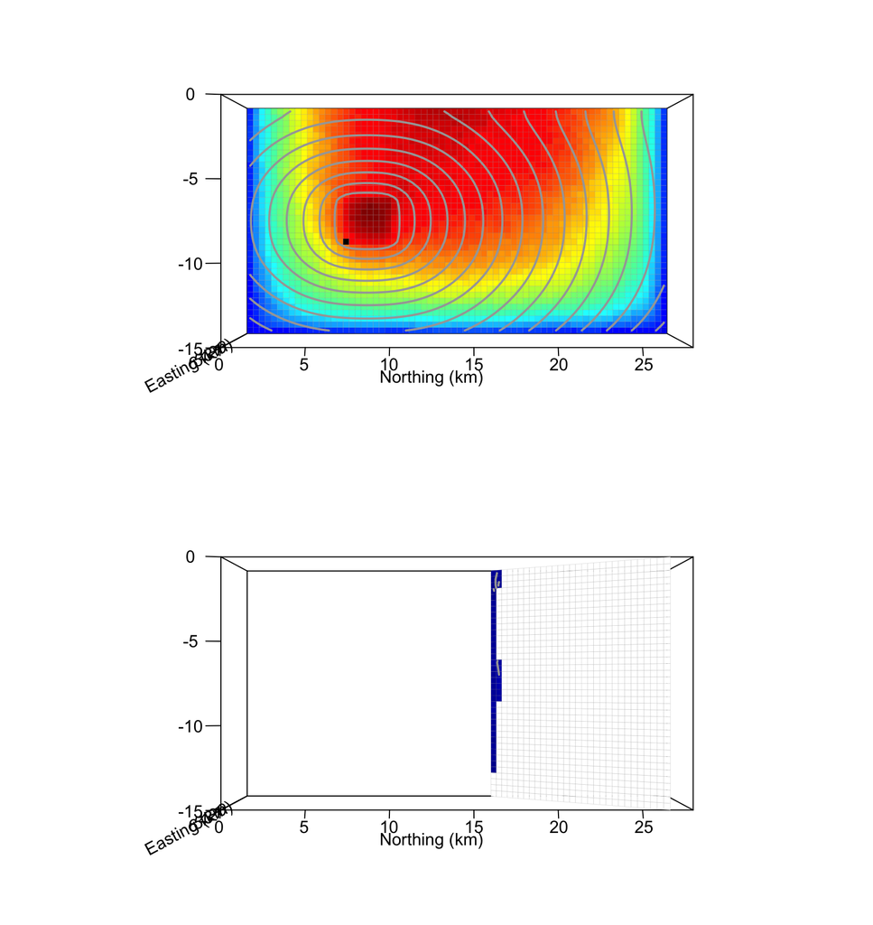

### Branch fault one element (400 m) away from main fault

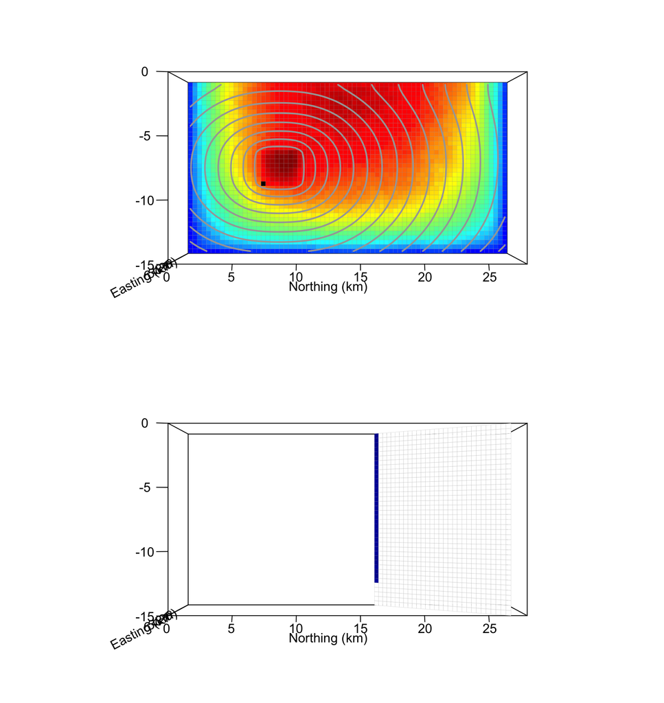

# To do

- differing resolutions
- variable slip speed